# Tutorial for calculating quantitative imaging biomarkers

Here is an illustration of implementation for finding imaging biomarkers using spatial random effect models.

## Simulate images

Suppose we collected images from $N=25$ patients, each having 32 by 32 pixels. We can convert the relative locations of pixels to grid points on $[-1,1]^2$. Note that the coordinate values of grid points are not important, but different patients’ coordinates should be compitable (maybe through registration) and are recorded as `loc`.

Let the underlying signal (without measurement errors) be patient-specific average plus a linear combination of two eigenfunctions:
$$y_j(\mathbf{s})= \mu_j + \theta_{j1}g_1(\mathbf{s})+ \theta_{j2}g_2(\mathbf{s}),$$

```r
N=25
loc=expand.grid(seq(-1,1,l=32),seq(-1,1,l=32))
loc=as.matrix(loc)
grids=loc
n=NROW(loc)
gh=matrix(0,n,2)
gh[,1]=sin(0.5*pi*(loc[,1]^2-loc[,2]^2))
gh[,2]=(1- ((grids[,1]-0.75)^2+(grids[,2]-0.75)^2)/4 )^2
set.seed(0)
theta=matrix(0,2,N)
for(j in 1:25) theta[,j]=c(rnorm(1,sd=3),rnorm(1,sd=1.5))
yj=rep(1,n)%x%t(rnorm(N,128,sd=5))+gh%*%theta
```

Assume that the measurement error variance is 1. The intensities on images are observed with errors.

```r
set.seed(0)
s=1
zj=yj+matrix(rnorm(n*N),n,N)*sqrt(s)
```

Take a look at the images of the 25 patients.

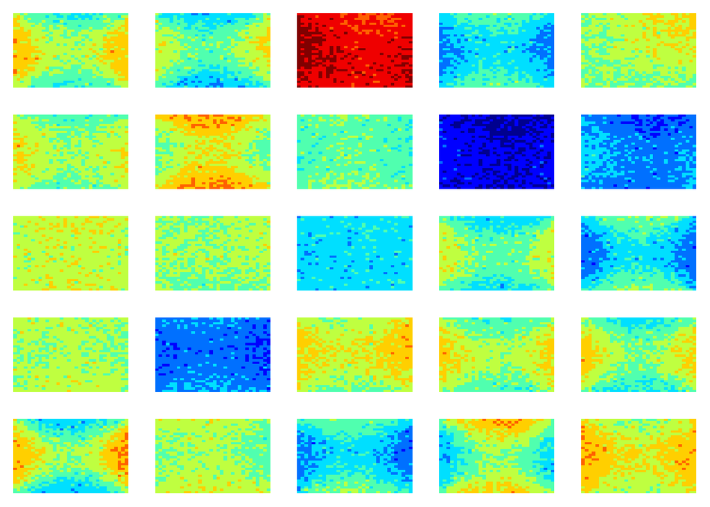

[figure not shown]

```r
library(fields)
par(mfrow=c(5,5),mar=c(1,1,1,1))
rng=range(zj)
for(j in 1:25)
image(matrix(zj[,j],32,32),col=tim.colors(10),zlim=rng,axes=F)
```

## Determine ROIs

Each patient has an ROI on her/his image. The following codes gernerate elliptical ROIs for patients. We put all patients’ images into an array (`zj`), and their ROIs are simply binary masks on individual images.

```r
set.seed(0)
axis1=runif(n=N)*0.5+0.25
axis2=runif(n=N)*0.5+0.25
corr=rnorm(n=N,0,0.5)
ROIs=array(0,c(32,32,N))
for(j in 1:N)
{
 #draw an ellipse based on axis1, axis2, and corr
 offdiag=axis1[j]*axis2[j]*corr[j]
 m=matrix(c(axis1[j],offdiag,offdiag,axis2[j]),2,2)
 r=diag(loc%*%m%*%t(loc))
 ROIs[,,j]=matrix((r<0.3)*1,32,32)
}
```

Take a look at the shapes of ROIs.

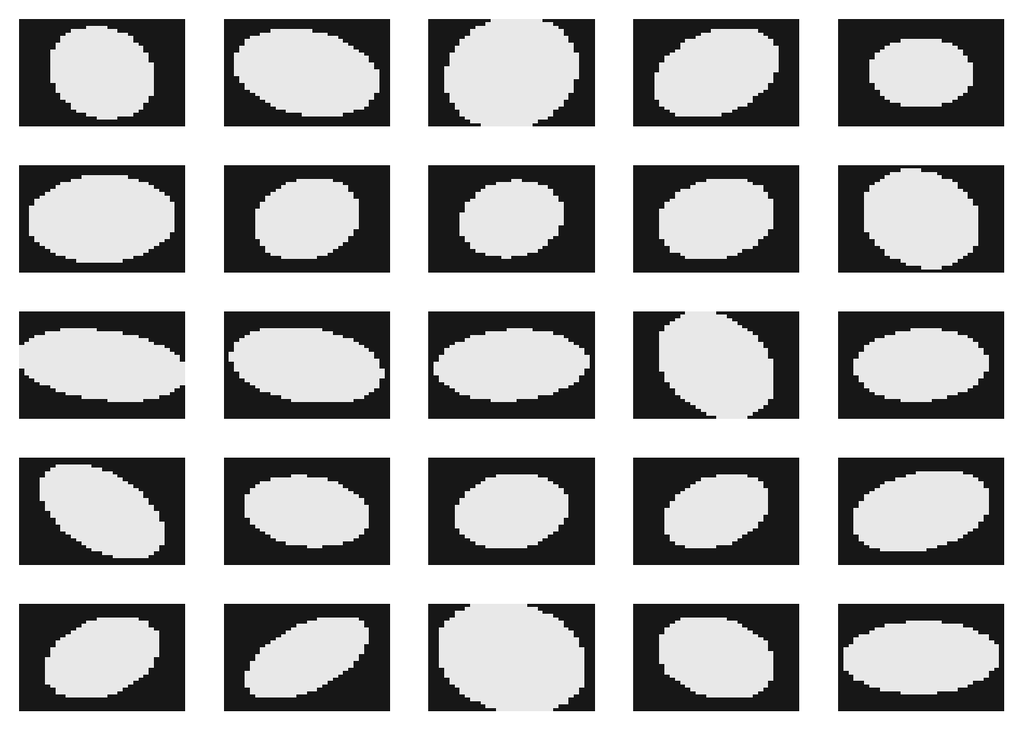

```r
par(mfrow=c(5,5),mar=c(1,1,1,1))
for(j in 1:25)
  image(ROIs[,,j],col=grey(1:10/11),axes=F)
```

## Fill NA to regions outside ROIs

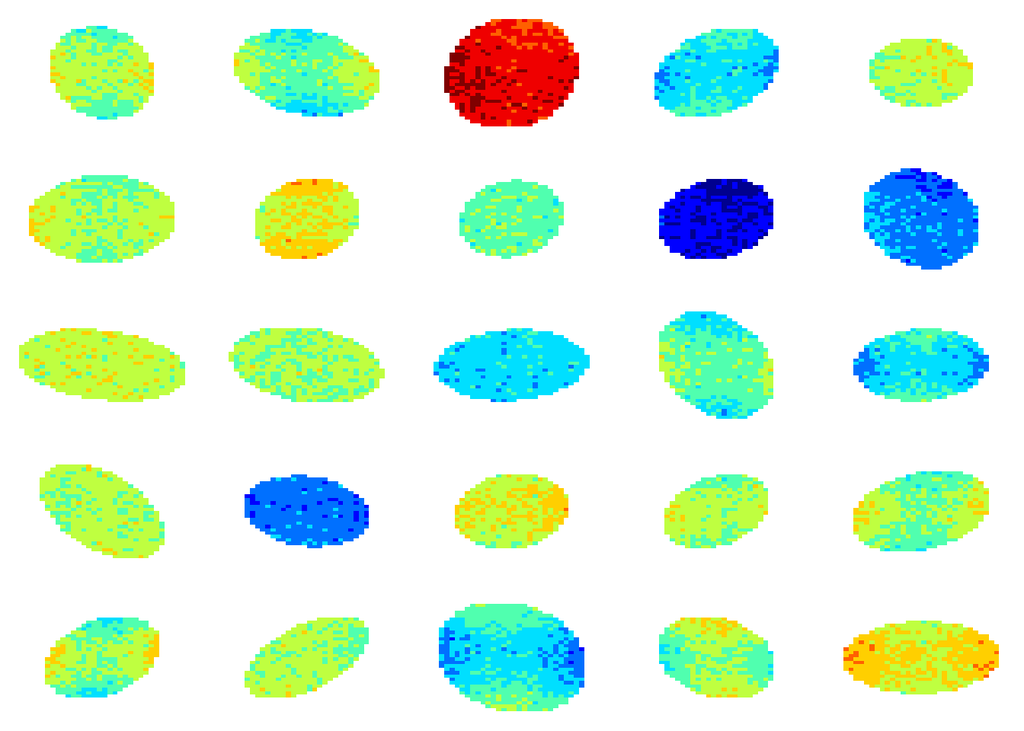

```r
par(mfrow=c(5,5),mar=c(1,1,1,1))
for(j in 1:25)
{
 zj[ROIs[,,j]==0,j]=NA
 image(matrix(zj[,j],32,32),col=tim.colors(10),zlim=rng, axes=F)
}
```

So these are the “input data” of our model.

## Find the union of ROIs and construct basis functions

Once the ROIs are identified, the first step is to determine the union of locations.

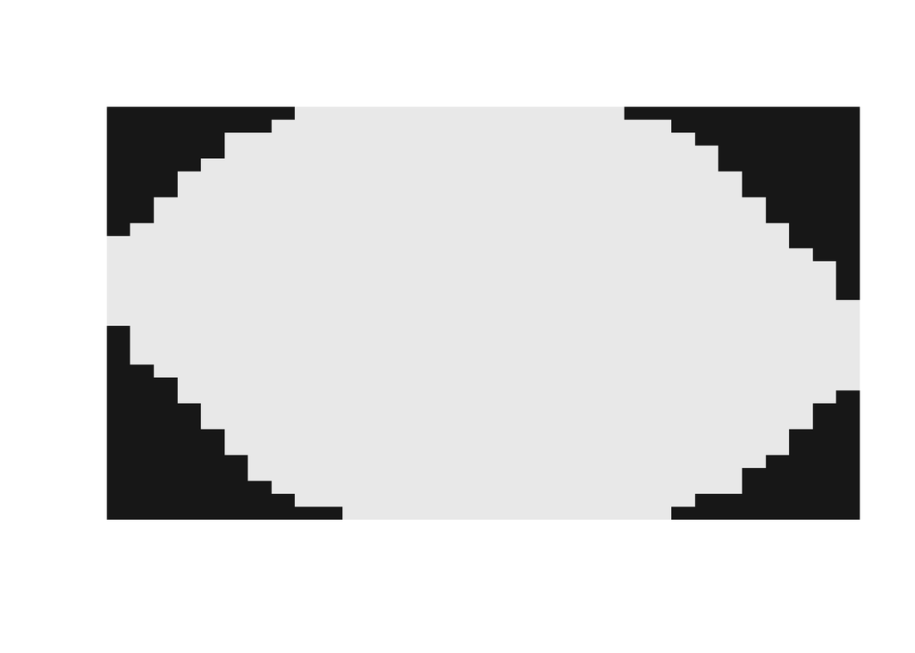

```r
pts=apply(ROIs,c(1,2),sum)
#the union is simply where pts>0
image(pts>0,col=grey(1:10/11),axes=F)
```

We utilize a package named `autoFRK` ($ 1.3.0$) for generating basis functions (10), and some routines in the EM-based estimation. Our implementation for basis function construction is given as `fbasis()`, whose input `knot` should be the union of locations, and `loc` is the matrix of locations you need for visulizing the component functions. Each row consists of a (coordinate vector of) location.

```r
library(autoFRK)
fbasis=function(Union,loc)
{
 n=NROW(unique(Union))
 Fk=mrts(Union,k=n, x=loc, maxknot=n)
 for(i in 1:n) Fk[,i]=Fk[,i]/sqrt(sum(Fk[,i]^2))
 return(Fk)
}
Union=loc[pts>0,]
B=fbasis(Union,loc)
```

## Model fitting

Before applying the EM algorithm to estimate parameters, we should subtract the sample mean from each patient’s data so as to have a zero average.

```r
zc=zj
for(j in 1:N) zc[,j]=zj[,j]-mean(zj[,j], na.rm=T)
```

Our implementation of the EM algorithm is given as `EMfit` below. The inputs and outputs are also briefly explained.

- Inputs:
  - `Fk` : the matrix of basis functions (by calling `fbasis`)
  - `Data` : a matrix where each column standing for a patient’s (centered) data
  - `maxit`: the upper bound for the number of iterations
  - `avgtol`: the convergence tolerance
- Outputs:
  - `M`: the estimated $\mathbf{M}$ matrix
  - `s`: the estimated $\sigma^2$
  - `n2loglik`: $-2 \cdot$ log-likelihood
  - `aic`: the AIC value

```r
EMfit=function(Fk,Data,maxit=50,avgtol=0.1^5,wSave=FALSE)
{
  O=!is.na(Data)
  TT=NCOL(Data)
  K=NCOL(Fk)
  Depsilon=diag(1,NROW(Data))

  library(autoFRK)
  Half=function(Fk,iDFk)
  {
   dec=eigen(t(Fk)%*%iDFk)
   sroot=sqrt(pmax(dec$value,0))
   sroot[sroot==0]=Inf
   sroot=1/sroot
   dec$vector%*%(sroot*t(dec$vector))
  }
  unlockBinding("getHalf", as.environment("package:autoFRK"))
  assignInNamespace("getHalf", Half, ns="autoFRK",
                    envir=as.environment("package:autoFRK"))
  assign("getHalf", Half, as.environment("package:autoFRK"))
  lockBinding("getHalf", as.environment("package:autoFRK"))

  SpMat=function(mat)
  {
   where=which(mat!=0)
   Matrix::spMatrix(nrow(mat),ncol(mat),
   row(mat)[where],col(mat)[where],mat[where])
  }
  getLik=function (Data, Fk, M, s)
  {
     logdet = function(R, L, K)
     {
        spam::determinant(diag(1, K) + t(L) %*% solve(R) %*% L,
                          logarithm = TRUE)$modulus +
      spam::determinant(R,logarithm = TRUE)$modulus
     }
     Data = as.matrix(Data)
     O = as.matrix(!is.na(Data))
     TT = NCOL(Data)
     n2loglik = sum(O) * log(2 * pi)
     R = SpMat(s * diag(1,NROW(Data)))
     eg = eigen((M+t(M))/2)
     L = Fk %*% eg$vector %*% diag(sqrt(pmax(eg$value, 0))) %*% t(eg$vector)
     K = NCOL(Fk)
     for (tt in 1:TT)
     {
        zt = Data[O[, tt], tt]
        Rt = R[O[, tt], O[, tt]]
        Lt = L[O[, tt], ]
        if (NCOL(Lt) == 1)
        {
            Lt = t(Lt)
            n2loglik = n2loglik + log(Rt + Lt %*% t(Lt))
        }   else
          n2loglik = n2loglik + logdet(Rt, Lt, K) +
             sum(zt * invCz(Rt, Lt, zt))
     }
    return(n2loglik)
  }

  Bs=list();  zs=list();
  nj=rep(NA,TT)
  zz=rep(NA,TT)                 #z'z
  zB=matrix(NA,TT,K)            #z'F
  BB=array(NA,c(K,K,TT))        #F'F

  for(tt in 1:TT)
  {
   Bs[[tt]]=Fk[O[,tt],]
   zs[[tt]]=Data[O[,tt],tt]
   zz[tt]=sum(zs[[tt]]^2)
   zB[tt,]=t(zs[[tt]])%*%Bs[[tt]]
   BB[,,tt]=t(Bs[[tt]])%*%Bs[[tt]]
   nj[tt]=length(zs[[tt]])
  }

  dif=Inf; cnt=0
  Z0=Data; Z0[is.na(Z0)]=0
    old=try( cMLEimat(Fk, Z0, s=0, onlylogLike = FALSE) ,silent=T)
    if(class(old)%in%"try-error")
    {
     old=cMLEimat(Fk, Z0, s=0.1^5, onlylogLike = FALSE)
     old$negloglik=Inf
    }
  if(sum(is.na(Data))==0)
  {
    if(K<=TT)  dfs=K*(K+1)/2  else  dfs=K*TT+1-TT*(TT-1)/2
    old$aic=old$negloglik+2*dfs
    old$s=old$v+old$s
    return(old)
  }

  eg=eigen((t(old$M)+old$M)/2)
  iniH=min(min(NCOL(Fk),TT), sum(eg$value > (old$s/mean(nj))))
  iniH=max(iniH,1)

  FF=apply(BB,c(1,2),sum)
  szz=sum(zz)
  nn=sum(nj)
  nc=min(iniH,K)
  if(nc==1) old$M=eg$vector[,1]%*%t(eg$vector[,1])*eg$value[1] else
  old$M=eg$vector[,1:nc]%*%diag(eg$value[1:nc])%*%t(eg$vector[,1:nc])
  old$s=(szz+sum(diag(FF%*%old$M)))/nn

  while(  (dif > (avgtol*K^2)) && (cnt<maxit)   )
  {
   etas=matrix(0,K,TT)
   Qs=array(0,c(K,K,TT))
   M=old$M
   eg=eigen((M+t(M))/2)
   rM=eg$vector%*%diag(sqrt(pmax(eg$value,0)))%*%t(eg$vector)
   for(tt in 1:TT)
   {
      MF=M%*%t(Bs[[tt]])
      L=Bs[[tt]]%*%rM
      sI=Diagonal(nj[tt], old$s)
      term1=as.matrix(invCz(sI, L,zs[[tt]]))
      term2=as.matrix(invCz(sI, L,t(MF)))
      etas[,tt]=MF%*%term1
      Qs[,,tt]=M-MF%*%term2
   }
   EE=etas%*%t(etas)
   M= (EE+ apply(Qs,c(1,2),sum))/TT
   s= (szz-sum(zB%*%etas))/nn
   if(s<0) s= (szz-2*sum(zB%*%etas)+sum(diag(M%*%FF)))/nn
   s= max(s,0.1^5)
   new=list(M=M,s=s)
   dif=sum(abs(new$M-old$M))+abs(new$s-old$s)
   cnt=cnt+1
   old=new
  }

  n2loglik=getLik(Data,Fk,new$M,new$s)
  if(K<=TT)  dfs=K*(K+1)/2 else     dfs=K*TT+1-TT*(TT-1)/2
  aic=n2loglik+2*dfs
  return(list(M=new$M,s=new$s, n2loglik=n2loglik, aic=aic))
}
```

An appropriate number of basis functions, $K$, can be found using codes like the chunk below, maybe with parallelization. It can take a while, and the codes of this part are commented for ease of illustration.

```r
#aics=rep(NA,sum(pts>0)/2)
#for( k in (NCOL(loc)+1):length(aics))
#  aics[k]=EMfit(Fk=B[pts>0,1:k], Data=zc[pts>0,])$aic
#K0=which.min(aics)
```

After calculating AIC values for quite a few $K$’s in model selection, we choose the model with $K=6$ as the final model, which has the smallest AIC.

```r
library(Matrix)
K0=6
mod=EMfit(Fk=B[pts>0,1:K0], Data=zc[pts>0,])
```

## Extract component functions and features

We also implement two function to extract $\hat{g}_h$’s and $\hat{\boldsymbol{\theta}}_j$, given as `getG()` and `getTheta()` respectively. Here is explanation of the inputs and outputs. Denote $\mathbf{s}_1,\ldots, \mathbf{s}_n$ the locations where the data were observed, and $\boldsymbol{\tau}_1,\ldots,\boldsymbol{\tau}_Q$ the locations that you need for visulizing the component functions.

- Inputs:
  - `mod` : result of fitted model (by calling `EMfit`)
  - `Bp` : a matrix with its $k$-th column $(f_k(\boldsymbol{\tau}_1),\ldots,f_k(\boldsymbol{\tau}_Q))^\prime$
  - `Bo` : a matrix with its $k$-th column $(f_k(\boldsymbol{s}_1),\ldots,f_k(\boldsymbol{s}_n))^\prime$
  - `H`: how many component to extract
  - `zc`: a matrix with each column a patient’s data after after subtracting the mean
- Outputs:
  - `ghat`: a matrix with its $h$-th column $(g_h(\boldsymbol{\tau}_1),...,g_h(\boldsymbol{\tau}_Q))^\prime$
  - `theta`: a matrix with its $j$-th row $(\hat{\theta}_{j1},...,\hat{\theta}_{jH})$

Note that the rows of `Bo` should match the loctions where rows of `zc` were observed.

```r
getG=function(mod, Bp, H)
{
 Fk=Bp
 Mhat=mod$M
 eg=eigen((Mhat+t(Mhat))/2)
 U=eg$vector
 ghat=Fk%*%U[,1:H]
 return(ghat)
}

getTheta=function(mod, Bo, zc, H)
{
  N=NCOL(zc)
  Mhat=mod$M
  eg=eigen((Mhat+t(Mhat))/2)
  Lambda=diag(eg$values[1:H])
  ghat=getG(mod, Bo, H)
  theta=matrix(0,N,H)
  for(j in 1:N)
  {
    oj=which(!is.na(zj[,j]))
    nj=length(oj)
    Gj=ghat[oj,]
    theta[j,]=Lambda%*%t(Gj)%*%solve(Gj%*%Lambda%*%t(Gj)+
              diag(mod$s,nj))%*%zc[oj,j]
  }
  return(theta)
}
```

Since the underlying process has two component functions, we compare the estimated $\hat{g}_h$’s and the true ones below. The negative signs before `ghat` on the last line merely reflect that a sign change of an eigenvector remains an eigenvector.

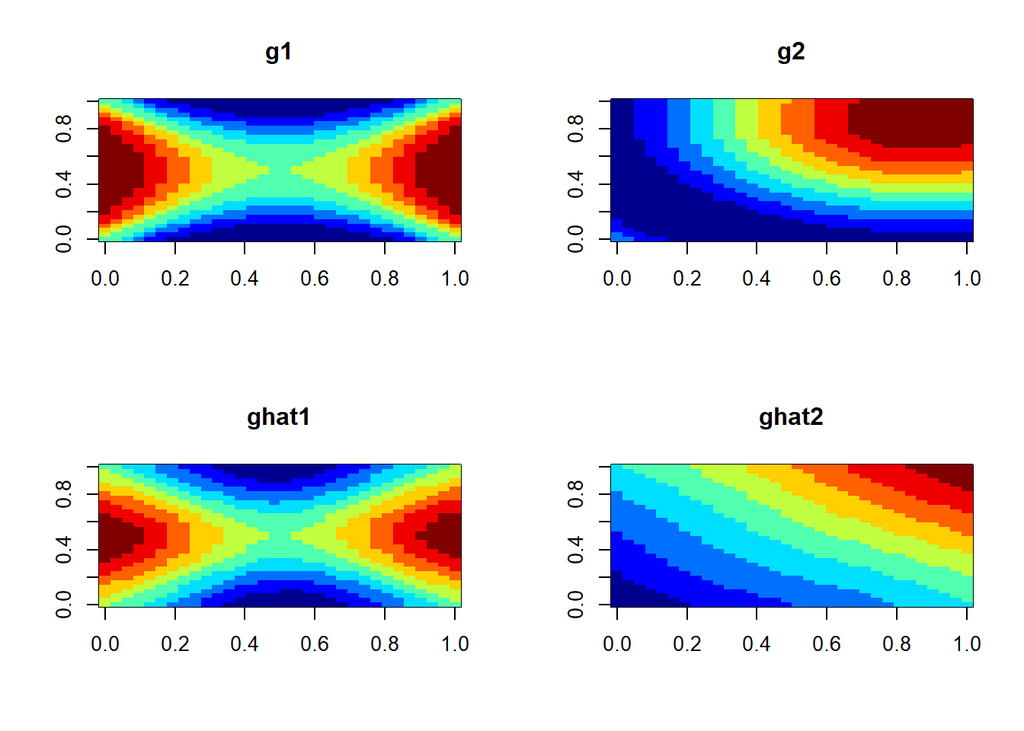

```r
ghat=getG(mod, Bp=B[,1:K0], H=2)

par(mfrow=c(2,2))
image(matrix(gh[,1],32,32),col=tim.colors(10), main="g1")
image(matrix(gh[,2],32,32),col=tim.colors(10), main="g2")
image(matrix(ghat[,1],32,32),col=tim.colors(10), main="ghat1")
image(matrix(-ghat[,2],32,32),col=tim.colors(10), main="ghat2")
```

And then extract the $\hat{\mu}_j$ and $\hat{\boldsymbol{\theta}}_j$ as the data-driven features.

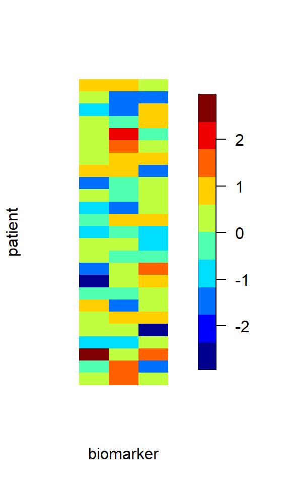

```r
mu=colMeans(zj,na.rm=T)
theta=getTheta(mod, Bo=B[,1:K0], zc, H=2)

#heatmap of features
par(mfrow=c(1,1))
feature=cbind(mu-mean(mu),theta)
biomarker=1:3
patient=1:N
image.plot(biomarker,patient,t(scale(feature,center=FALSE)), col=tim.colors(10),axes=FALSE)
```